# kerneldensity_demo

During my Master's thesis, I collected data depicting the dispersal of individual snails from three different points of release over the course of five days, which ended up being 9 low tides after release. For two of the locations, the distance dispersed could be modeled by probability density functions but for one location, the spread of individual snails from the first tide after release onwards looked multimodal and could not be effectively modeled with a simple probability density function. Below I outline my process of modelling some of this data with kernel density estimation.

```python
import pandas as pd
import numpy as np
import matplotlib.pyplot as plt
import seaborn as sns
import warnings

from scipy.stats._continuous_distns import _distn_names
import scipy.stats as st
import scipy as sp
import matplotlib

from scipy.stats import gaussian_kde

from sklearn.model_selection import GridSearchCV
from sklearn.model_selection import LeaveOneOut
from sklearn.neighbors import KernelDensity
```

```python
# Import data
df = pd.read_excel(r'dispersal_data.xlsx', sheet_name='cobble')
```

```python
# Check data imported successfully
df.head()
```

|  | location | 0 | 1 | 3 | 5 | 7 | 9 |
| --- | --- | --- | --- | --- | --- | --- | --- |
| 0 | place2_c | 0 | 4.0 | 7.0 | NaN | 8.0 | 9.0 |
| 1 | place2_c | 0 | 3.0 | 5.0 | NaN | 8.0 | 8.0 |
| 2 | place2_c | 0 | 3.0 | 5.0 | 9.0 | 9.0 | NaN |
| 3 | place2_c | 0 | 3.0 | 3.0 | 3.0 | 3.0 | 4.0 |
| 4 | place2_c | 0 | 4.0 | NaN | 4.0 | 4.0 | 7.0 |

```python
# Drop the columns that include location and location at release
df = df.drop(columns=['location',0])
```

I imported all the packages that we would need and then the data. After checking that the data imported successfully, I lightly cleaned it by removing the first two columns. The column 'location' held the information for which one of the three locations these snails were released at, and the column '0' showed the distance from the release point each snail was at the 0th tide (the release day). The other columns are the distance in metres at 1m intervals (up to 10m) from the release point after a specific number of low tides (e.g. column '5' is the distance in metres from the release point five low tides after release).

Below, I graphed the data directly from the cleaned dataframe to show the distribution of individuals at the different distances. From these graphs, the slightly bimodal shape can be seen.

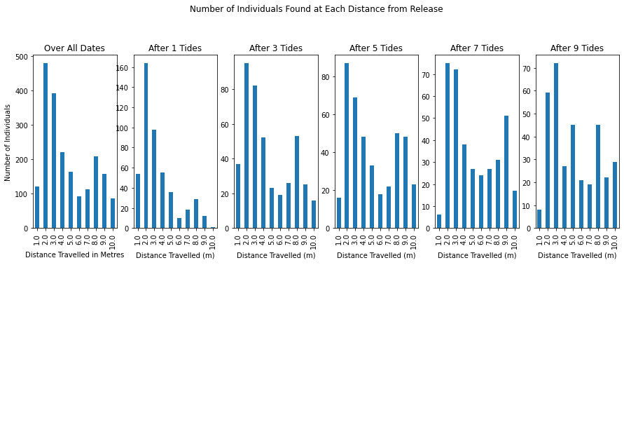

```python
total_counts = df.apply(pd.value_counts).sum(axis=1)

fig, ax = plt.subplots(2, 6, sharex = False, figsize=(15,10))
fig.suptitle('Number of Individuals Found at Each Distance from Release')
total_counts.plot.bar(ax=ax[0,0])
ax[0,0].set_title('Over All Dates')
ax[0,0].set_ylabel('Number of Individuals')
ax[0,0].set_xlabel('Distance Travelled in Metres')
ax[1,0].axis('off')

x_axis = 1

for columnName, columnData in df.iteritems():
    counts = df[columnName].value_counts().sort_index()
    counts.plot.bar(ax=ax[0,x_axis])
    ax[0,x_axis].set_title('After ' + str(columnName) + ' Tides')
    ax[0,x_axis].set_xlabel('Distance Travelled (m)')
    ax[1,x_axis].axis('off')
    x_axis += 1
```

After graphing the data, the logical next step would be to find the best fit distribution using probability density functions.

```python
# Function that takes as input a list of data and the number of bins
# Returns the best fit distribution, its parameters, and its sum of squared estimate of errors (SSE)
# The best fit distribution is determined based on the lowest SSE
# Tries all continuous distributions in scipy.stats
def get_best_distribution(data, bins=50):
    data = data.dropna()
    y, x = np.histogram(data, bins=bins, density=True)
    x = np.linspace(0,10,50)

    # Best holders
    best_distributions = []

    with warnings.catch_warnings():
        warnings.simplefilter("ignore")
        for index, distribution in enumerate([d for d in _distn_names if not d in ['levy_stable', 'studentized_range']]):
            print("{:>3} / {:<3}: {}".format(index+1, len(_distn_names), distribution))
            distribution = getattr(st, distribution)

            try:
                params = distribution.fit(data)
                arg = params[:-2]
                loc = params[-2]
                scale = params[-1]

                pdf = distribution.pdf(x, loc=loc, scale=scale, *arg)
                sse = np.sum(np.power(y - pdf, 2.0))

                best_distributions.append([distribution, params, sse])

            except Exception:
                pass

    best = sorted(best_distributions, key=lambda x:x[1])
    best = best[0]

    return best
```

```python
# Find best fit distribution for the distribution of individuals after 5 tides
best = get_best_distribution(df[5])
# See which distribution is best
best
```

[output not shown]

[output cut: 87 more lines]

```
[<scipy.stats._continuous_distns.kstwobign_gen at 0x123f76ee0>,
 (-4.110766209125432, 10.442304993576183),
 3.542003543645172]
```

```python
# Initialize y,x
y, x1 = np.histogram(df[1].dropna(), bins=50, density=True)
x = np.linspace(0,10,50)

# Find the pdf using the parameters from the best distribution
params = best[1]
pdf = sp.stats.kstwobign.pdf(x, params[0], params[1])
```

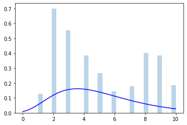

```python
# Plot the pdf with data
fig, ax = plt.subplots()
plt.plot(x, pdf, 'b-')
plt.hist(df[5].dropna(),bins=30,density=True,alpha=.3)
```

The above graph shows very clearly that the data on the right side of the data is not adequately modelled using the best probability density function found. In this case, I believe that using a kernel density estimation would provide a better fit. Next, I use `seaborns` to plot a graph to demonstrate that indeed, a kernel density estimatino would be better.

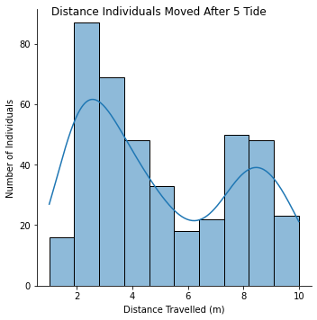

```python
sns.displot(data=df, x=5, kde=True)
plt.suptitle("Distance Individuals Moved After 5 Tide")
plt.xlabel("Distance Travelled (m)")
plt.ylabel("Number of Individuals")
```

Now that I've seen what the kernel density estimation of my data could look like, I turn to using `scipy` to actually perform my kernel density estimation.

```python
# Function that takes in data, grid used for plotting, and bandwidth
# Returns the values at each point for the kde
def kde_scipy(x, x_grid, bandwidth=0.2, **kwargs):
    kde = gaussian_kde(x, bw_method=bandwidth, **kwargs)
    return kde.evaluate(x_grid)
```

The kernel density estimation calculation uses a bandwidth and different bandwidths can lead to vastly different results, as seen in the graph below.

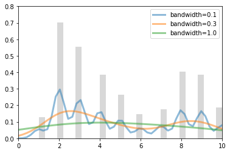

```python
# Plot data alongside the kde at different bandwidths
fig, ax = plt.subplots()
for bandwidth in [0.1, 0.3, 1.0]:
    ax.plot(x, kde_scipy(df[5].dropna(), x, bandwidth),
            label='bandwidth={0}'.format(bandwidth), linewidth=3, alpha=0.5)
ax.hist(df[5].dropna(), 30, fc='gray', histtype='stepfilled', alpha=0.3, density=True)
ax.set_xlim(0,10)
ax.set_ylim(0,0.8)
ax.legend(loc='upper right')
```

Given that varying the bandwidth between 0.1 and 1.0 can produce such different results and that I do not have any references for what the best bandwidth for this data would be, I use cross-validation to find the best bandwidth. In cross validation, the model is fit to part of the data, and then a quantitative metric is computed to determine how well this model fits the remaining data. This should then provide the best bandwidth fit for our estimation.

```python
# Scikit-learn GridSearchCV meta-estimator
bandwidths = 10 ** np.linspace(-1, 1, 100)
grid = GridSearchCV(KernelDensity(kernel='gaussian'),
                    {'bandwidth': bandwidths},
                    cv=LeaveOneOut())

# Get column from dataframe and reshape
data = df[5].dropna().tolist()
data = np.reshape(data, (-1, 1))
# Grid search cross-validation using reshaped data
grid.fit(data)
```

```
GridSearchCV(cv=LeaveOneOut(), estimator=KernelDensity(),
             param_grid={'bandwidth': array([ 0.1       ,  0.10476158,  0.10974988,  0.1149757 ,  0.12045035,
        0.12618569,  0.13219411,  0.13848864,  0.14508288,  0.15199111,
        0.15922828,  0.16681005,  0.17475284,  0.18307383,  0.19179103,
        0.2009233 ,  0.21049041,  0.22051307,  0.23101297,  0.24201283,
        0.25353645,  0.26560878,  0.27825594,  0.29150531,  0.305385...
        2.05651231,  2.15443469,  2.25701972,  2.36448941,  2.47707636,
        2.59502421,  2.71858824,  2.84803587,  2.98364724,  3.12571585,
        3.27454916,  3.43046929,  3.59381366,  3.76493581,  3.94420606,
        4.1320124 ,  4.32876128,  4.53487851,  4.75081016,  4.97702356,
        5.21400829,  5.46227722,  5.72236766,  5.9948425 ,  6.28029144,
        6.57933225,  6.8926121 ,  7.22080902,  7.56463328,  7.92482898,
        8.30217568,  8.69749003,  9.11162756,  9.54548457, 10.        ])})
```

```python
# Show best bandwidth
grid.best_params_
```

```
{'bandwidth': 0.1}
```

Cross-validation shows that the best bandwidth to use is 0.1m. This does give the most exact fit to the data, as seen when I plotted the kernel density estimations using bandwidths of 0.1, 0.3, and 1.0. What can also be seen is that the lower the bandwidth, the more exact the line plotted from the estimation follows the data but the higher the bandwidth, the smoother the plotted line is.

In this situation, the data collected was in 1 metre increments due to natural constraints of what data is feasible to collect in the field. We would assume that the areas between each metre increment would follow a smooth distribution. Therefore, we use a bandwidth slightly larger than 0.1 to smooth out the areas where we have missing data but do not lose the bimodal shape.

This process can be repeated with the data collected from after different numbers of tides or for the data as a whole.

```python
# Using scipy calculate the values of the kde
kde = kde_scipy(df[5].dropna(), x, bandwidth=0.2)
```

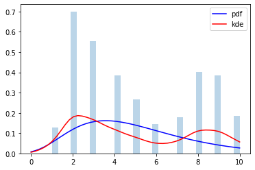

```python
# Plot the data, kde, and pdf
plt.plot(x, pdf, 'b-', label='pdf')
plt.plot(x, kde, 'r-', label='kde')
plt.hist(df[5].dropna(),bins=30,density=True,alpha=.3)
plt.legend()
```